# Practical Machine Learning - Peer-Graded Assignment

Oguzhan Erken

11/18/2020

# I. Overview

This report is written for the Practical Machine Learning Course from Coursera. RStudio is used as the environment and both Rmd and html versions are included in the GitHub repository. The main objective of the project is to build a prediction model for the training manner of 6 participants. The detailed information about the recorded data and training exercise can be found below. The developed model is used applied to 20 test cases as part of the Practical Machine Learning course.

# II. Background and Data

## II.a. Background

“Using devices such as Jawbone Up, Nike FuelBand, and Fitbit it is now possible to collect a large amount of data about personal activity relatively inexpensively. These type of devices are part of the quantified self movement – a group of enthusiasts who take measurements about themselves regularly to improve their health, to find patterns in their behavior, or because they are tech geeks. One thing that people regularly do is quantify how much of a particular activity they do, but they rarely quantify how well they do it. In this project, your goal will be to use data from accelerometers on the belt, forearm, arm, and dumbell of 6 participants. They were asked to perform barbell lifts correctly and incorrectly in 5 different ways. More information is available from the website here: http://web.archive.org/web/20161224072740/http:/groupware.les.inf.puc-rio.br/har (see the section on the Weight Lifting Exercise Dataset).”

## II.a. Data

"The training data for this project are available here:

https://d396qusza40orc.cloudfront.net/predmachlearn/pml-training.csv

The test data are available here:

https://d396qusza40orc.cloudfront.net/predmachlearn/pml-testing.csv "

Create a model to predict the manner in which the subjects did the exercise using the accelerometer data as predictors. The outcome to be predicted is the “classe” variable.

# III. Purpose

In this project, a model is going to be built in order to predict the manner of the subjects during their exercises. Accelerometer data, which includes bicep curls data for our case, will be used as predictors. The participants were each instructed to perform the exercise either properly (Class A) or in a way which replicated 4 common weightlifting mistakes (Classes B, C, D, and E). “classe” variable is the outcome to be predicted.

**Full Citation:** Velloso, E.; Bulling, A.; Gellersen, H.; Ugulino, W.; Fuks, H. Qualitative Activity Recognition of Weight Lifting Exercises. Proceedings of 4th International Conference in Cooperation with SIGCHI (Augmented Human ’13) . Stuttgart, Germany: ACM SIGCHI, 2013.

# IV. Prepare Data for Prediction and Validations Steps

## IV.a. Load Libraries

```r
knitr::opts_chunk$set(fig.width=18, fig.height=12, warning=FALSE, message=FALSE)
library(knitr)
library(caret)
library(rpart)
library(rpart.plot)
library(rattle)
library(RColorBrewer)
library(randomForest)
library(e1071)
library(gbm)
library(corrplot)
```

## IV.b. Load and Clean Data

```r
set.seed(1923)
# Create url variables from the given url of data
TrainingUrl <- "http://d396qusza40orc.cloudfront.net/predmachlearn/pml-training.csv"
ValidationUrl  <- "http://d396qusza40orc.cloudfront.net/predmachlearn/pml-testing.csv"

# Load data to training and testing variables
trainingData <- read.csv(url(TrainingUrl))
validationData  <- read.csv(url(ValidationUrl))
```

Prepare data partitions from the training data set. Given testing set will only be used to test the built model and it will be left over during the model preparation. Therefore, training data will be divided into training and testing sets again. 30% of the data will be allocated for testing set.

```r
inTrain <- createDataPartition(trainingData$classe, p=0.7, list=FALSE)
training <- trainingData[inTrain, ]
testing <- trainingData[-inTrain, ]
dim(training); dim(testing)
```

```
## [1] 13737   160
```

```
## [1] 5885  160
```

From the given data, NA, Near Zero Variance (NZV) and ID variables are going to be removed. Firstly remove NZV:

```r
nzv <- nearZeroVar(training)
training <- training[, -nzv]
testing  <- testing[, -nzv]
dim(training); dim(testing)
```

```
## [1] 13737   105
```

```
## [1] 5885  105
```

Now, variables that are formed of mostly NA will be removed:

```r
AllNA    <- sapply(training, function(x) mean(is.na(x))) > 0.95
training <- training[, AllNA==FALSE]
testing  <- testing[, AllNA==FALSE]
dim(training); dim(testing)
```

```
## [1] 13737    59
```

```
## [1] 5885   59
```

Since columns from 1 to 5 includes only identification variables, they are removed here:

```r
training <- training[, -(1:5)]
testing  <- testing[, -(1:5)]
dim(training); dim(testing)
```

```
## [1] 13737    54
```

```
## [1] 5885   54
```

Cleaning procedure is complete. Now, correlation of the variables will be explored and analyzed.

## IV.c. Check Correlation

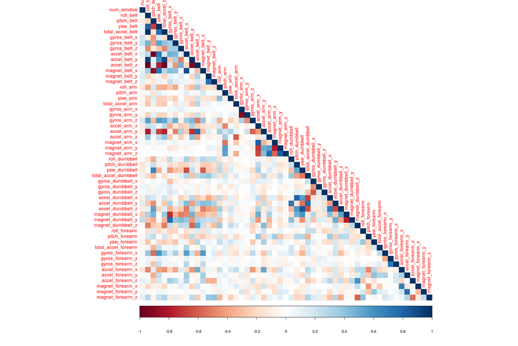

```r
corMatrix <- cor(training[, -54])
corrplot(corMatrix, method = "color", type = "lower")
```

When the correlation plot is analyzed, it can be seen that some of the variables are highly correlated. Therefore, those will be removed from the dataset (0.85 is chosen as the threshold).

```r
c <- findCorrelation(corMatrix, cutoff = .85)
training <- training[,-c]
testing <- testing[,-c]
dim(training); dim(testing)
```

```
## [1] 13737    47
```

```
## [1] 5885   47
```

# V. Preparation of the Prediction Model

After loading and cleaning the data processes are performed, next step is to build the prediction model and perform cross validation. Three different methods are going to be used for the model building, which are random forest, decision tree and boosting. Models are going to be compared and the model with the highest accuracy is going to be used on the Validation set.

## V.a. Decision Tree

[figure not shown]

```r
# fit
set.seed(1923)
fitDT <- rpart(classe ~ ., data=training, method="class")
fancyRpartPlot(fitDT)
```

```r
# prediction
predDT <- predict(fitDT, newdata=testing, type="class")
confMatDT <- confusionMatrix(predDT, testing$classe)
confMatDT
```

```
## Confusion Matrix and Statistics
##
##           Reference
## Prediction    A    B    C    D    E
##          A 1473  138   10   26   63
##          B  104  586  103   94  166
##          C   37  253  884  175  207
##          D   55  145   29  636  128
##          E    5   17    0   33  518
##
## Overall Statistics
##
##                Accuracy : 0.6962
##                  95% CI : (0.6842, 0.7079)
##     No Information Rate : 0.2845
##     P-Value [Acc > NIR] : < 2.2e-16
##
##                   Kappa : 0.6159
##
##  Mcnemar's Test P-Value : < 2.2e-16
##
## Statistics by Class:
##
##                      Class: A Class: B Class: C Class: D Class: E
## Sensitivity            0.8799  0.51449   0.8616   0.6598  0.47874
## Specificity            0.9437  0.90160   0.8617   0.9275  0.98855
## Pos Pred Value         0.8614  0.55651   0.5681   0.6405  0.90401
## Neg Pred Value         0.9519  0.88555   0.9672   0.9330  0.89383
## Prevalence             0.2845  0.19354   0.1743   0.1638  0.18386
## Detection Rate         0.2503  0.09958   0.1502   0.1081  0.08802
## Detection Prevalence   0.2906  0.17893   0.2644   0.1687  0.09737
## Balanced Accuracy      0.9118  0.70804   0.8616   0.7936  0.73365
```

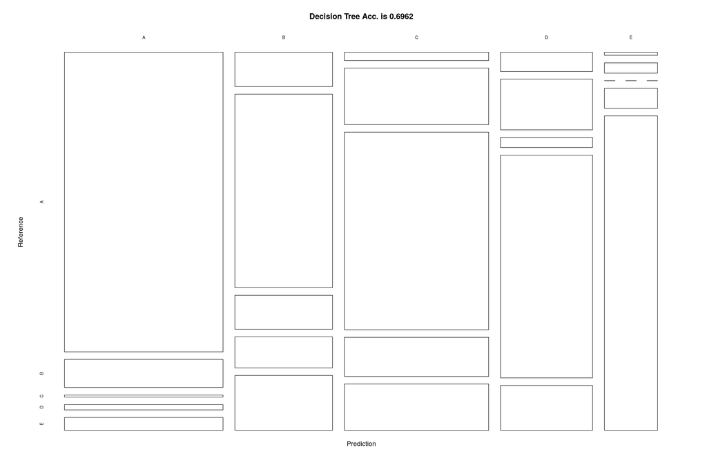

```r
# plot matrix results
plot(confMatDT$table, col = confMatDT$byClass,
     main = paste("Decision Tree Acc. is", round(confMatDT$overall['Accuracy'], 4)))
```

## V.b. Boosting Model

```r
# fit
set.seed(1923)
controlBM <- trainControl(method = "repeatedcv", number = 5, repeats = 1)
fitBM  <- train(classe ~ ., data=training, method = "gbm",
                    trControl = controlBM, verbose = FALSE)
fitBM$finalModel
```

```
## A gradient boosted model with multinomial loss function.
## 150 iterations were performed.
## There were 46 predictors of which 46 had non-zero influence.
```

```r
# prediction
predBM <- predict(fitBM, newdata=testing)
confMatBM <- confusionMatrix(predBM, testing$classe)
confMatBM
```

```
## Confusion Matrix and Statistics
##
##           Reference
## Prediction    A    B    C    D    E
##          A 1672    8    0    0    0
##          B    2 1118   15    8    1
##          C    0   11 1009    9    2
##          D    0    2    2  946    9
##          E    0    0    0    1 1070
##
## Overall Statistics
##
##                Accuracy : 0.9881
##                  95% CI : (0.985, 0.9907)
##     No Information Rate : 0.2845
##     P-Value [Acc > NIR] : < 2.2e-16
##
##                   Kappa : 0.985
##
##  Mcnemar's Test P-Value : NA
##
## Statistics by Class:
##
##                      Class: A Class: B Class: C Class: D Class: E
## Sensitivity            0.9988   0.9816   0.9834   0.9813   0.9889
## Specificity            0.9981   0.9945   0.9955   0.9974   0.9998
## Pos Pred Value         0.9952   0.9773   0.9787   0.9864   0.9991
## Neg Pred Value         0.9995   0.9956   0.9965   0.9963   0.9975
## Prevalence             0.2845   0.1935   0.1743   0.1638   0.1839
## Detection Rate         0.2841   0.1900   0.1715   0.1607   0.1818
## Detection Prevalence   0.2855   0.1944   0.1752   0.1630   0.1820
## Balanced Accuracy      0.9985   0.9880   0.9895   0.9893   0.9944
```

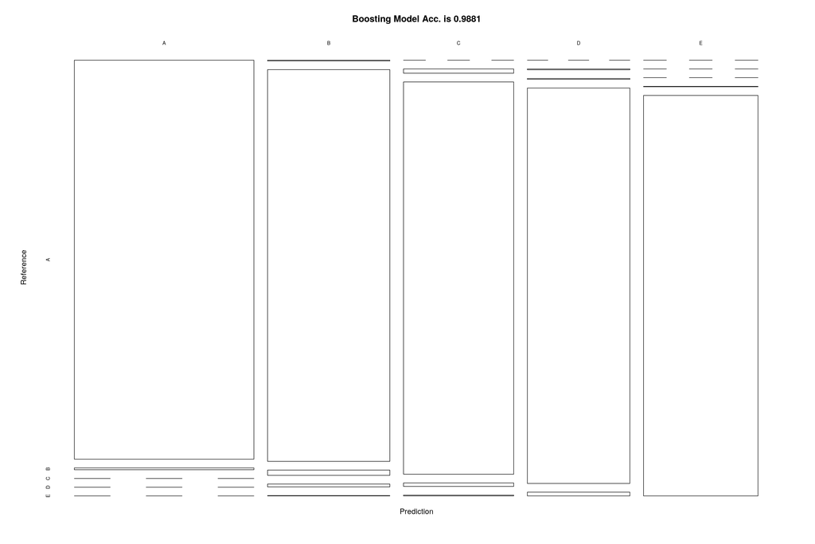

```r
# plot matrix results
plot(confMatBM$table, col = confMatBM$byClass,
     main = paste("Boosting Model Acc. is", round(confMatBM$overall['Accuracy'], 4)))
```

## V.c. Random Forest

```r
# fit
set.seed(1923)
controlRF <- trainControl(method="cv", number=3, verboseIter=FALSE)
fitRF <- train(classe ~ ., data=training, method="rf", trControl=controlRF)
fitRF$finalModel
```

```
##
## Call:
##  randomForest(x = x, y = y, mtry = param$mtry)
##                Type of random forest: classification
##                      Number of trees: 500
## No. of variables tried at each split: 24
##
##         OOB estimate of  error rate: 0.25%
## Confusion matrix:
##      A    B    C    D    E  class.error
## A 3905    0    0    0    1 0.0002560164
## B    7 2646    5    0    0 0.0045146727
## C    0    8 2386    2    0 0.0041736227
## D    0    0   10 2242    0 0.0044404973
## E    0    0    0    2 2523 0.0007920792
```

```r
# prediction
predRF <- predict(fitRF, newdata=testing)
confMatRF <- confusionMatrix(predRF, testing$classe)
confMatRF
```

```
## Confusion Matrix and Statistics
##
##           Reference
## Prediction    A    B    C    D    E
##          A 1672    2    0    0    0
##          B    1 1137    1    0    0
##          C    0    0 1025    2    0
##          D    0    0    0  961    0
##          E    1    0    0    1 1082
##
## Overall Statistics
##
##                Accuracy : 0.9986
##                  95% CI : (0.9973, 0.9994)
##     No Information Rate : 0.2845
##     P-Value [Acc > NIR] : < 2.2e-16
##
##                   Kappa : 0.9983
##
##  Mcnemar's Test P-Value : NA
##
## Statistics by Class:
##
##                      Class: A Class: B Class: C Class: D Class: E
## Sensitivity            0.9988   0.9982   0.9990   0.9969   1.0000
## Specificity            0.9995   0.9996   0.9996   1.0000   0.9996
## Pos Pred Value         0.9988   0.9982   0.9981   1.0000   0.9982
## Neg Pred Value         0.9995   0.9996   0.9998   0.9994   1.0000
## Prevalence             0.2845   0.1935   0.1743   0.1638   0.1839
## Detection Rate         0.2841   0.1932   0.1742   0.1633   0.1839
## Detection Prevalence   0.2845   0.1935   0.1745   0.1633   0.1842
## Balanced Accuracy      0.9992   0.9989   0.9993   0.9984   0.9998
```

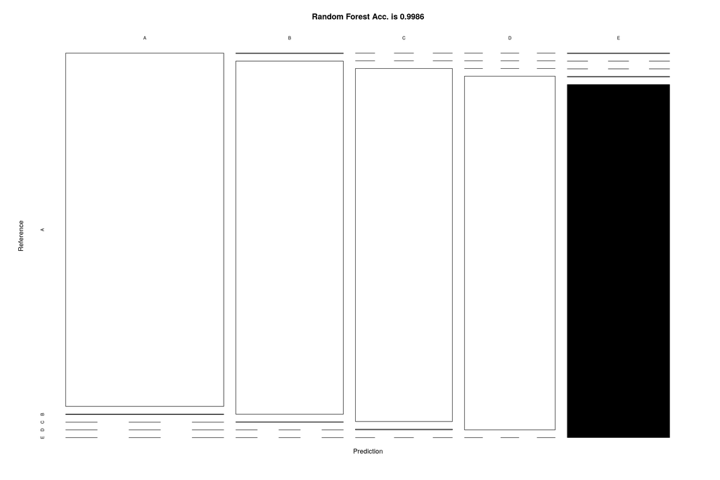

```r
# plot matrix results
plot(confMatRF$table, col = confMatRF$byClass,
     main = paste("Random Forest Acc. is", round(confMatRF$overall['Accuracy'], 4)))
```

## VI. Validation of the Prediction Model with the Given Testing Data

The accuracy of the tried models are: 1) Decision Tree: 0.6962 2) Boosting Model: 0.9881 3) Random Forest: 0.9986

As can be seen, boosting model and random forest performed very well on the training data. Since, accuracy of the random forest is a little bit higher, this model is going to be applied to the validation data.

```r
predictTEST <- predict(fitRF, newdata=validationData)
predictTEST
```

```
##  [1] B A B A A E D B A A B C B A E E A B B B
## Levels: A B C D E
```